# Sana_module1_19042023

2023-04-19

ALY6015 CRN 80403  
Intermediate Analytics  
NORTHEASTERN UNIVERSITY  
SANA YASIN  
Date :26 April, 2023  
**MODULE 1 -Regression Diagnostic with R**  
Professor: Richard He

**INTRODUCTION :-**

In this project we are going fit, interpret and evaluate linear regression model on AmesHousing dataset. We are also going to implement diagnostic techniques to identify and correct issues with the model.

**LOADING PACKAGES AND DATASETS:-**

```
## Rows: 5
## Columns: 81
## $ `MS SubClass`     <chr> "020", "020", "020", "020", "060"
## $ `MS Zoning`       <chr> "RL", "RH", "RL", "RL", "RL"
## $ `Lot Frontage`    <dbl> 141, 80, 81, 93, 74
## $ `Lot Area`        <dbl> 31770, 11622, 14267, 11160, 13830
## $ Street            <chr> "Pave", "Pave", "Pave", "Pave", "Pave"
## $ Alley             <chr> NA, NA, NA, NA, NA
## $ `Lot Shape`       <chr> "IR1", "Reg", "IR1", "Reg", "IR1"
## $ `Land Contour`    <chr> "Lvl", "Lvl", "Lvl", "Lvl", "Lvl"
## $ Utilities         <chr> "AllPub", "AllPub", "AllPub", "AllPub", "AllPub"
## $ `Lot Config`      <chr> "Corner", "Inside", "Corner", "Corner", "Inside"
## $ `Land Slope`      <chr> "Gtl", "Gtl", "Gtl", "Gtl", "Gtl"
## $ Neighborhood      <chr> "NAmes", "NAmes", "NAmes", "NAmes", "Gilbert"
## $ `Condition 1`     <chr> "Norm", "Feedr", "Norm", "Norm", "Norm"
```

[output cut: 68 more lines]

The dataset contains 2930 rows and 81 columns.

**SUMMARY TABLES FOR CATEGORICAL VARIABLES**  
In the Dataset, we have 80 columns which include 23 nominal, 23 ordinal, 14 discrete, and 20 continuous variables (and 2 additional observation identifiers which we removed earlier).

To create summary tables we have seperated the categorical variables and created tables for each of the variables .

We have replaced the Null values with “N/A”.

|  | MS SubClass |
| --- | --- |
|  | 020 :1079 |
|  | 060 : 575 |
|  | 050 : 287 |
|  | 120 : 192 |
|  | 030 : 139 |
|  | 160 : 129 |
|  | (Other): 529 |

|  | Street |
| --- | --- |
|  | Grvl: 12 |
|  | Pave:2918 |

|  | MS Zoning |
| --- | --- |
|  | A (agr): 2 |
|  | C (all): 25 |
|  | FV : 139 |
|  | I (all): 2 |
|  | RH : 27 |
|  | RL :2273 |
|  | RM : 462 |

[output not shown]

[output not shown]

[output not shown]

|  | Alley |
| --- | --- |
|  | Grvl: 120 |
|  | N/A :2732 |
|  | Pave: 78 |

|  | Lot Shape |
| --- | --- |
|  | IR1: 979 |
|  | IR2: 76 |
|  | IR3: 16 |
|  | Reg:1859 |

|  | Land Contour |
| --- | --- |
|  | Bnk: 117 |
|  | HLS: 120 |
|  | Low: 60 |
|  | Lvl:2633 |

|  | Utilities |
| --- | --- |
|  | AllPub:2927 |
|  | NoSeWa: 1 |
|  | NoSewr: 2 |

|  | Lot Config |
| --- | --- |
|  | Corner : 511 |
|  | CulDSac: 180 |
|  | FR2 : 85 |
|  | FR3 : 14 |
|  | Inside :2140 |

|  | Land Slope |
| --- | --- |
|  | Gtl:2789 |
|  | Mod: 125 |
|  | Sev: 16 |

|  | Condition 1 |
| --- | --- |
|  | Norm :2522 |
|  | Feedr : 164 |
|  | Artery : 92 |
|  | RRAn : 50 |
|  | PosN : 39 |
|  | RRAe : 28 |
|  | (Other): 35 |

|  | Condition 2 |
| --- | --- |
|  | Norm :2900 |
|  | Feedr : 13 |
|  | Artery : 5 |
|  | PosA : 4 |
|  | PosN : 4 |
|  | RRNn : 2 |
|  | (Other): 2 |

|  | Bldg Type |
| --- | --- |
|  | 1Fam :2425 |
|  | 2fmCon: 62 |
|  | Duplex: 109 |
|  | Twnhs : 101 |
|  | TwnhsE: 233 |

|  | House Style |
| --- | --- |
|  | 1Story :1481 |
|  | 2Story : 873 |
|  | 1.5Fin : 314 |
|  | SLvl : 128 |
|  | SFoyer : 83 |
|  | 2.5Unf : 24 |
|  | (Other): 27 |

|  | Roof Style |
| --- | --- |
|  | Flat : 20 |
|  | Gable :2321 |
|  | Gambrel: 22 |
|  | Hip : 551 |
|  | Mansard: 11 |
|  | Shed : 5 |

|  | Roof Matl |
| --- | --- |
|  | CompShg:2887 |
|  | Tar&Grv: 23 |
|  | WdShake: 9 |
|  | WdShngl: 7 |
|  | ClyTile: 1 |
|  | Membran: 1 |
|  | (Other): 2 |

|  | Exterior 1st |
| --- | --- |
|  | VinylSd:1026 |
|  | MetalSd: 450 |
|  | HdBoard: 442 |
|  | Wd Sdng: 420 |
|  | Plywood: 221 |
|  | CemntBd: 126 |
|  | (Other): 245 |

|  | Exterior 2nd |
| --- | --- |
|  | VinylSd:1015 |
|  | MetalSd: 447 |
|  | HdBoard: 406 |
|  | Wd Sdng: 397 |
|  | Plywood: 274 |
|  | CmentBd: 126 |
|  | (Other): 265 |

|  | Mas Vnr Type |
| --- | --- |
|  | BrkCmn : 25 |
|  | BrkFace: 880 |
|  | CBlock : 1 |
|  | N/A : 23 |
|  | None :1752 |
|  | Stone : 249 |

|  | Exter Qual |
| --- | --- |
|  | Ex: 107 |
|  | Fa: 35 |
|  | Gd: 989 |
|  | TA:1799 |

|  | Exter Cond |
| --- | --- |
|  | Ex: 12 |
|  | Fa: 67 |
|  | Gd: 299 |
|  | Po: 3 |
|  | TA:2549 |

|  | Foundation |
| --- | --- |
|  | BrkTil: 311 |
|  | CBlock:1244 |
|  | PConc :1310 |
|  | Slab : 49 |
|  | Stone : 11 |
|  | Wood : 5 |

|  | Bsmt Qual |
| --- | --- |
|  | Ex : 258 |
|  | Fa : 88 |
|  | Gd :1219 |
|  | N/A: 80 |
|  | Po : 2 |
|  | TA :1283 |

|  | Bsmt Cond |
| --- | --- |
|  | Ex : 3 |
|  | Fa : 104 |
|  | Gd : 122 |
|  | N/A: 80 |
|  | Po : 5 |
|  | TA :2616 |

|  | Bsmt Exposure |
| --- | --- |
|  | Av : 418 |
|  | Gd : 284 |
|  | Mn : 239 |
|  | N/A: 83 |
|  | No :1906 |

|  | BsmtFin Type 1 |
| --- | --- |
|  | ALQ:429 |
|  | BLQ:269 |
|  | GLQ:859 |
|  | LwQ:154 |
|  | N/A: 80 |
|  | Rec:288 |
|  | Unf:851 |

|  | Overall Qual |
| --- | --- |
|  | 5 :825 |
|  | 6 :732 |
|  | 7 :602 |
|  | 8 :350 |
|  | 4 :226 |
|  | 9 :107 |
|  | (Other): 88 |

|  | BsmtFin Type 2 |
| --- | --- |
|  | ALQ: 53 |
|  | BLQ: 68 |
|  | GLQ: 34 |
|  | LwQ: 89 |
|  | N/A: 81 |
|  | Rec: 106 |
|  | Unf:2499 |

|  | Overall Cond |
| --- | --- |
|  | 5 :1654 |
|  | 6 : 533 |
|  | 7 : 390 |
|  | 8 : 144 |
|  | 4 : 101 |
|  | 3 : 50 |
|  | (Other): 58 |

|  | Bsmt Full Bath |
| --- | --- |
|  | 0 :1707 |
|  | 1 :1181 |
|  | 2 : 38 |
|  | 3 : 2 |
|  | NA’s: 2 |

|  | Bsmt Half Bath |
| --- | --- |
|  | 0 :2753 |
|  | 1 : 171 |
|  | 2 : 4 |
|  | NA’s: 2 |

|  | Bedroom AbvGr |
| --- | --- |
|  | 3 :1597 |
|  | 2 : 743 |
|  | 4 : 400 |
|  | 1 : 112 |
|  | 5 : 48 |
|  | 6 : 21 |
|  | (Other): 9 |

|  | Kitchen AbvGr |
| --- | --- |
|  | 0: 3 |
|  | 1:2796 |
|  | 2: 129 |
|  | 3: 2 |

|  | Heating |
| --- | --- |
|  | Floor: 1 |
|  | GasA :2885 |
|  | GasW : 27 |
|  | Grav : 9 |
|  | OthW : 2 |
|  | Wall : 6 |

|  | Heating QC |
| --- | --- |
|  | Ex:1495 |
|  | Fa: 92 |
|  | Gd: 476 |
|  | Po: 3 |
|  | TA: 864 |

|  | Central Air |
| --- | --- |
|  | N: 196 |
|  | Y:2734 |

|  | Electrical |
| --- | --- |
|  | N/A : 1 |
|  | NA’s:2929 |

|  | Kitchen Qual |
| --- | --- |
|  | Ex: 205 |
|  | Fa: 70 |
|  | Gd:1160 |
|  | Po: 1 |
|  | TA:1494 |

|  | Functional |
| --- | --- |
|  | Typ :2728 |
|  | Min2 : 70 |
|  | Min1 : 65 |
|  | Mod : 35 |
|  | Maj1 : 19 |
|  | Maj2 : 9 |
|  | (Other): 4 |

|  | Fireplace Qu |
| --- | --- |
|  | Ex : 43 |
|  | Fa : 75 |
|  | Gd : 744 |
|  | N/A:1422 |
|  | Po : 46 |
|  | TA : 600 |

|  | Garage Type |
| --- | --- |
|  | 2Types : 23 |
|  | Attchd :1731 |
|  | Basment: 36 |
|  | BuiltIn: 186 |
|  | CarPort: 15 |
|  | Detchd : 782 |
|  | N/A : 157 |

|  | Garage Finish |
| --- | --- |
|  | Fin: 728 |
|  | N/A: 159 |
|  | RFn: 812 |
|  | Unf:1231 |

|  | Garage Qual |
| --- | --- |
|  | Ex : 3 |
|  | Fa : 124 |
|  | Gd : 24 |
|  | N/A: 159 |
|  | Po : 5 |
|  | TA :2615 |

|  | Garage Cond |
| --- | --- |
|  | Ex : 3 |
|  | Fa : 74 |
|  | Gd : 15 |
|  | N/A: 159 |
|  | Po : 14 |
|  | TA :2665 |

|  | Paved Drive |
| --- | --- |
|  | N: 216 |
|  | P: 62 |
|  | Y:2652 |

|  | Pool QC |
| --- | --- |
|  | Ex : 4 |
|  | Fa : 2 |
|  | Gd : 4 |
|  | N/A:2917 |
|  | TA : 3 |

|  | Fence |
| --- | --- |
|  | GdPrv: 118 |
|  | GdWo : 112 |
|  | MnPrv: 330 |
|  | MnWw : 12 |
|  | N/A :2358 |

|  | Misc Feature |
| --- | --- |
|  | Elev: 1 |
|  | Gar2: 5 |
|  | N/A :2824 |
|  | Othr: 4 |
|  | Shed: 95 |
|  | TenC: 1 |

|  | Sale Type |
| --- | --- |
|  | WD :2536 |
|  | New : 239 |
|  | COD : 87 |
|  | ConLD : 26 |
|  | CWD : 12 |
|  | ConLI : 9 |
|  | (Other): 21 |

|  | Sale Condition |
| --- | --- |
|  | Abnorml: 190 |
|  | AdjLand: 12 |
|  | Alloca : 24 |
|  | Family : 46 |
|  | Normal :2413 |
|  | Partial: 245 |

**SUMMARY TABLES FOR NUMERICAL VARIABLES**  
To create summary tables we have separated the numerical variables and created tables for each of the variables .  
We have replaced the Null values with zeros.

[output not shown]

```
##    Min. 1st Qu.  Median    Mean 3rd Qu.    Max.
##    1300    7440    9436   10148   11555  215245
```

```
##    Min. 1st Qu.  Median    Mean 3rd Qu.    Max.
##     0.0     0.0     0.0   101.1   162.8  1600.0
```

```
##    Min. 1st Qu.  Median    Mean 3rd Qu.    Max.
##     0.0     0.0   370.0   442.5   734.0  5644.0
```

```
##    Min. 1st Qu.  Median    Mean 3rd Qu.    Max.
##    0.00    0.00    0.00   49.71    0.00 1526.00
```

```
##    Min. 1st Qu.  Median    Mean 3rd Qu.    Max.
##     0.0   219.0   465.5   559.1   801.8  2336.0
```

```
##    Min. 1st Qu.  Median    Mean 3rd Qu.    Max.
##       0     793     990    1051    1302    6110
```

```
##    Min. 1st Qu.  Median    Mean 3rd Qu.    Max.
##   334.0   876.2  1084.0  1159.6  1384.0  5095.0
```

```
##    Min. 1st Qu.  Median    Mean 3rd Qu.    Max.
##     0.0     0.0     0.0   335.5   703.8  2065.0
```

```
##     Min.  1st Qu.   Median     Mean  3rd Qu.     Max.
##    0.000    0.000    0.000    4.677    0.000 1064.000
```

```
##    Min. 1st Qu.  Median    Mean 3rd Qu.    Max.
##     334    1126    1442    1500    1743    5642
```

```
##    Min. 1st Qu.  Median    Mean 3rd Qu.    Max.
##     0.0   320.0   480.0   472.7   576.0  1488.0
```

```
##    Min. 1st Qu.  Median    Mean 3rd Qu.    Max.
##    0.00    0.00    0.00   93.75  168.00 1424.00
```

```
##    Min. 1st Qu.  Median    Mean 3rd Qu.    Max.
##    0.00    0.00   27.00   47.53   70.00  742.00
```

```
##    Min. 1st Qu.  Median    Mean 3rd Qu.    Max.
##    0.00    0.00    0.00   23.01    0.00 1012.00
```

```
##    Min. 1st Qu.  Median    Mean 3rd Qu.    Max.
##   0.000   0.000   0.000   2.592   0.000 508.000
```

```
##    Min. 1st Qu.  Median    Mean 3rd Qu.    Max.
##       0       0       0      16       0     576
```

```
##    Min. 1st Qu.  Median    Mean 3rd Qu.    Max.
##   0.000   0.000   0.000   2.243   0.000 800.000
```

```
##     Min.  1st Qu.   Median     Mean  3rd Qu.     Max.
##     0.00     0.00     0.00    50.63     0.00 17000.00
```

```
##    Min. 1st Qu.  Median    Mean 3rd Qu.    Max.
##   13.00   22.00   50.00   51.64   69.00  151.00
```

```
##    Min. 1st Qu.  Median    Mean 3rd Qu.    Max.
##   12789  129500  160000  180796  213500  755000
```

**EXPLORATORY DATA ANALYSIS**  
The objective of this project is to create linear regression model. For this we need to establish the relation between our target variable “SalesPrice” and predictors variables.Before creating the model we need to examine the predictors graphically . So we will using:-

1.Scatter plot:- To visualize correlation between target and predictor variables.

2.Box Plot:-To examine outliers and variation with respect to categorical variables.

3.Density Plot :- To check the normality of Distributions.

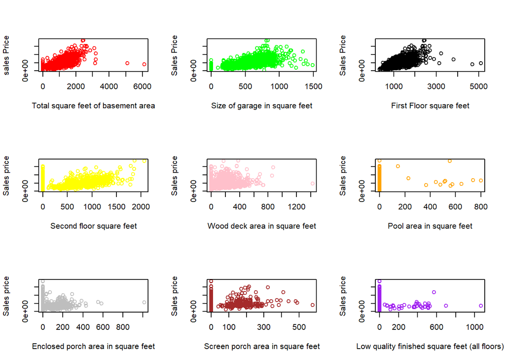

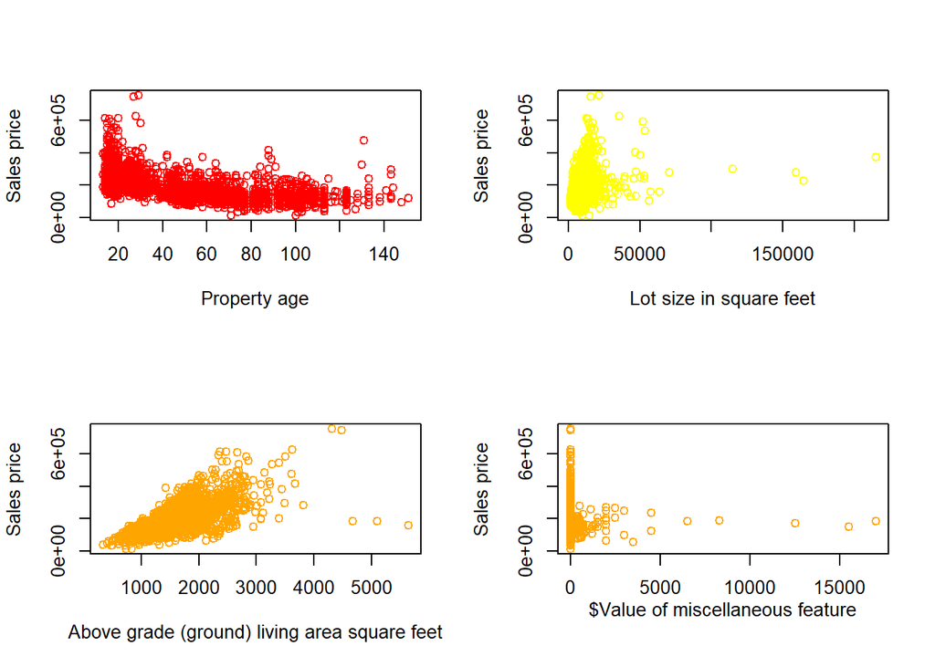

**OBSERVATION**

The variables `Total Bsmt SF`,`1st Flr SF`,`2nd Flr SF`,`Wood Deck SF`,`Gr Liv Area` vary directly with target variable `SalesPrice`.  
The variable `Property_age` vary negatively with target variable.

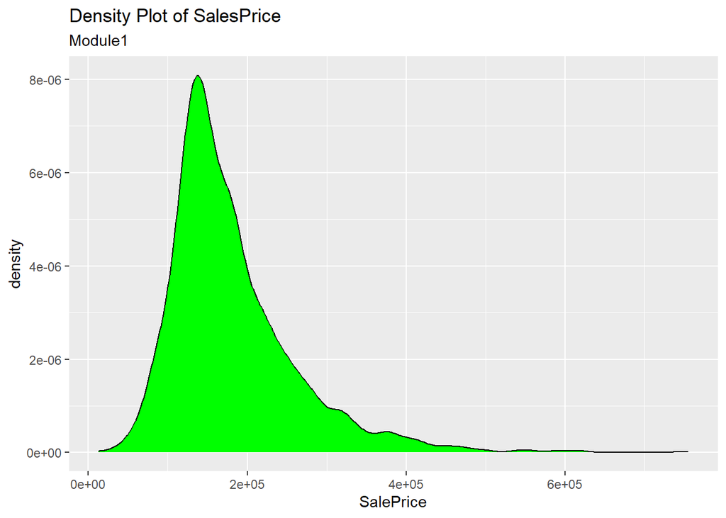

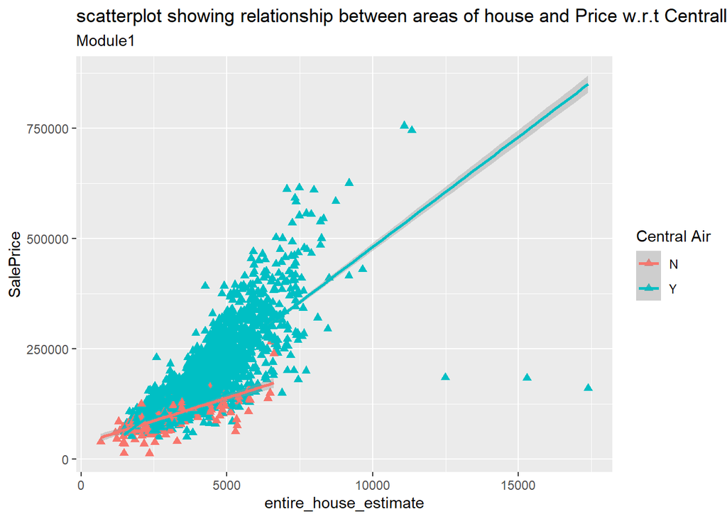

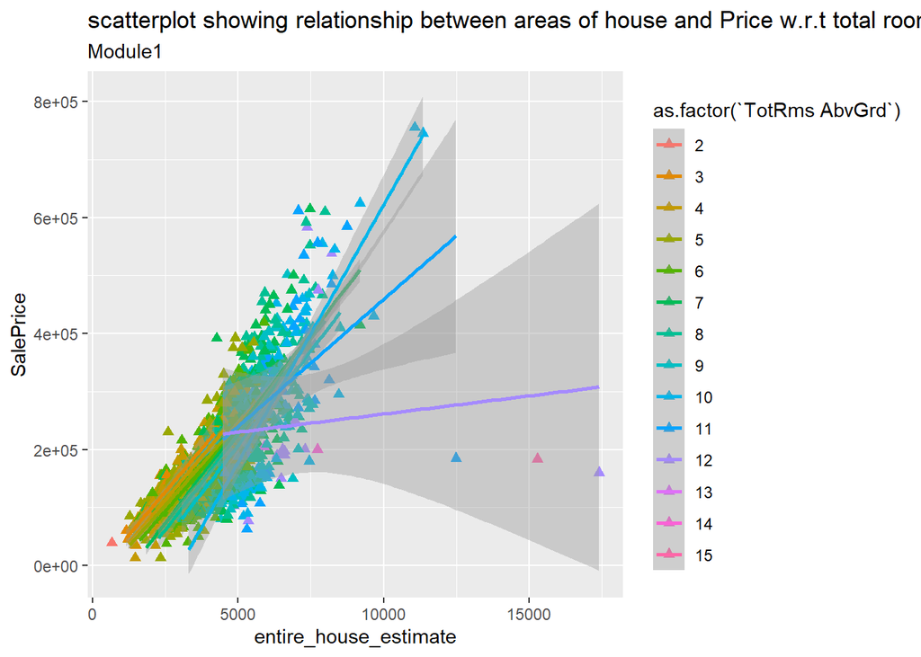

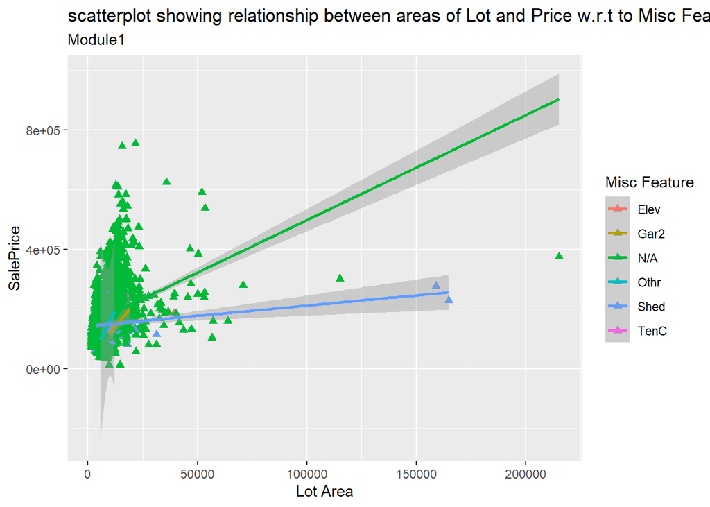

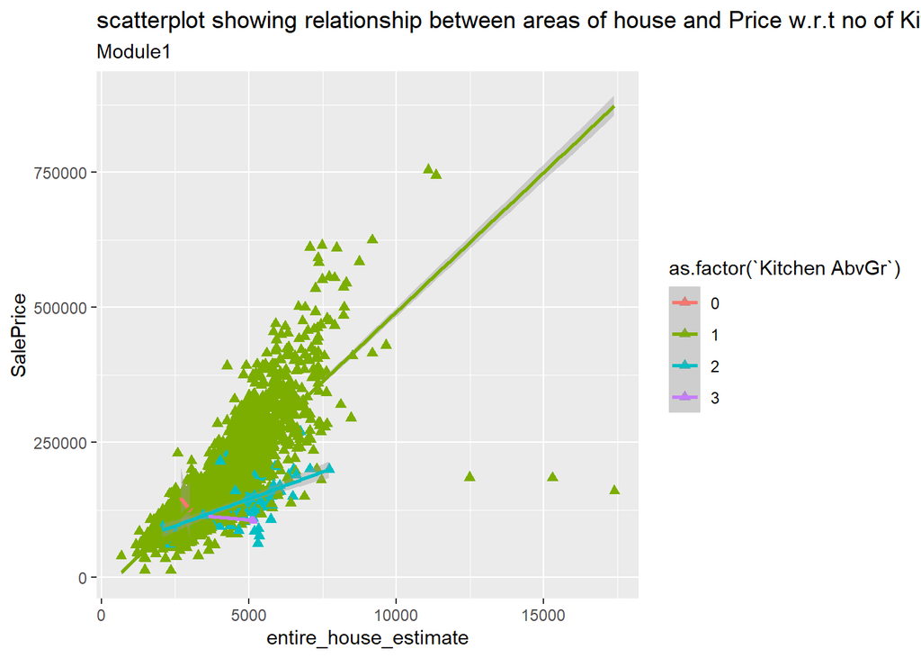

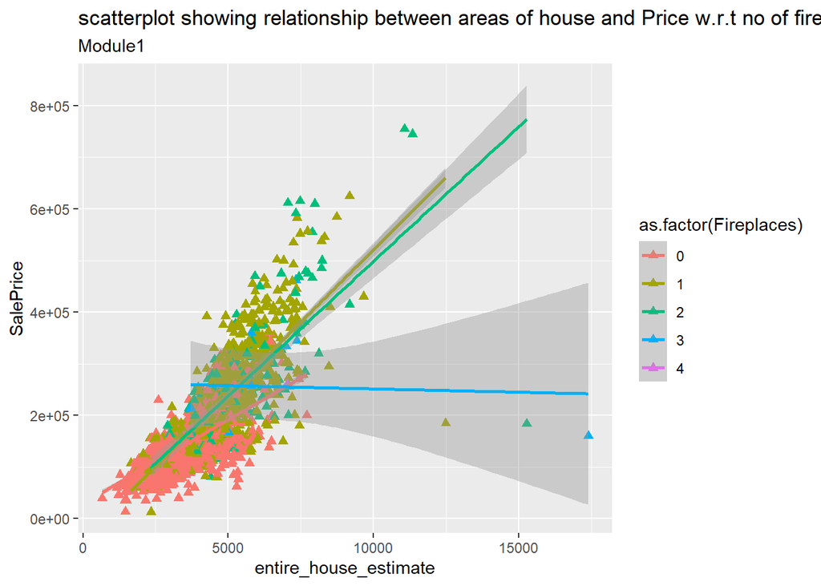

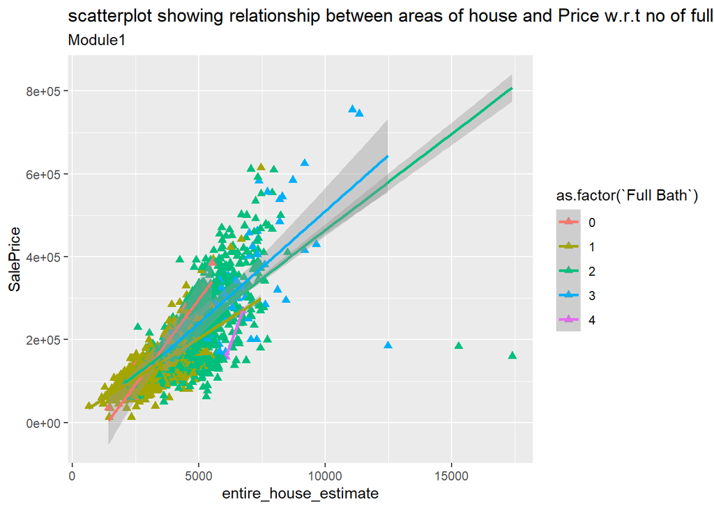

**CORRELATION MATRIX:-**

Correlation is statistical measure of linear dependence between 2 variables . It takes values between +1 to -1. We need to test and plot the correlation matrix for our predictor variables and target variables.

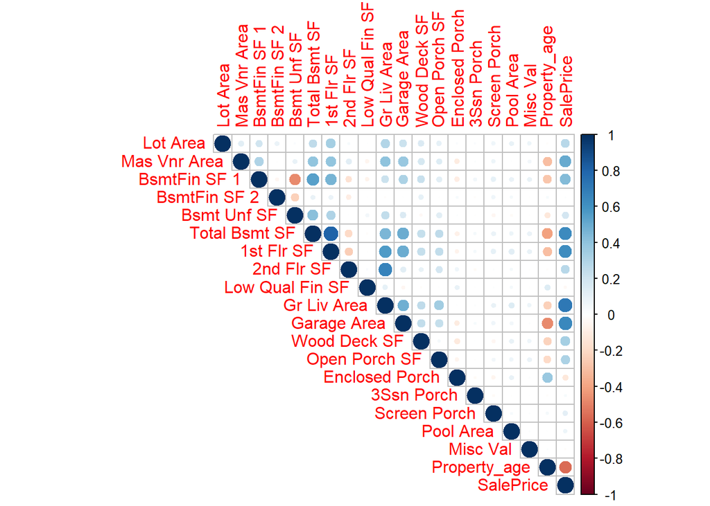

```
##
##  Pearson's product-moment correlation
##
## data:  AmesHousing_cor$SalePrice and AmesHousing_cor$`Total Bsmt SF`
## t = 44.19, df = 2928, p-value < 2.2e-16
## alternative hypothesis: true correlation is not equal to 0
## 95 percent confidence interval:
##  0.6102961 0.6537660
## sample estimates:
##       cor
## 0.6325288
```

```
##
##  Pearson's product-moment correlation
##
## data:  AmesHousing_cor$SalePrice and AmesHousing_cor$`Gr Liv Area`
## t = 54.061, df = 2928, p-value < 2.2e-16
## alternative hypothesis: true correlation is not equal to 0
## 95 percent confidence interval:
##  0.6881814 0.7244502
## sample estimates:
##       cor
## 0.7067799
```

```
##
##  Pearson's product-moment correlation
##
## data:  AmesHousing_cor$SalePrice and AmesHousing_cor$Property_age
## t = -36.426, df = 2928, p-value < 2.2e-16
## alternative hypothesis: true correlation is not equal to 0
## 95 percent confidence interval:
##  -0.5828515 -0.5329925
## sample estimates:
##        cor
## -0.5584261
```

```
##
##  Pearson's product-moment correlation
##
## data:  AmesHousing_cor$SalePrice and AmesHousing_cor$`1st Flr SF`
## t = 42.947, df = 2928, p-value < 2.2e-16
## alternative hypothesis: true correlation is not equal to 0
## 95 percent confidence interval:
##  0.5989480 0.6434034
## sample estimates:
##       cor
## 0.6216761
```

```
##
##  Pearson's product-moment correlation
##
## data:  AmesHousing_cor$SalePrice and AmesHousing_cor$`2nd Flr SF`
## t = 15.136, df = 2928, p-value < 2.2e-16
## alternative hypothesis: true correlation is not equal to 0
## 95 percent confidence interval:
##  0.2354586 0.3026329
## sample estimates:
##       cor
## 0.2693734
```

```
##
##  Pearson's product-moment correlation
##
## data:  AmesHousing_cor$SalePrice and AmesHousing_cor$`Open Porch SF`
## t = 17.83, df = 2928, p-value < 2.2e-16
## alternative hypothesis: true correlation is not equal to 0
## 95 percent confidence interval:
##  0.2799111 0.3452495
## sample estimates:
##       cor
## 0.3129505
```

```
##
##  Pearson's product-moment correlation
##
## data:  AmesHousing_cor$SalePrice and AmesHousing_cor$`Wood Deck SF`
## t = 18.733, df = 2928, p-value < 2.2e-16
## alternative hypothesis: true correlation is not equal to 0
## 95 percent confidence interval:
##  0.2944194 0.3591007
## sample estimates:
##       cor
## 0.3271432
```

**LINEAR REGRESSION MODEL**

```
##
## Call:
## lm(formula = SalePrice ~ `Total Bsmt SF` + `Gr Liv Area` + Property_age +
##     `1st Flr SF` + `2nd Flr SF` + `Open Porch SF` + `Wood Deck SF`,
##     data = AmesHousing)
##
## Residuals:
##     Min      1Q  Median      3Q     Max
## -624356  -20484   -2851   16797  272113
##
## Coefficients:
##                  Estimate Std. Error t value Pr(>|t|)
## (Intercept)     48033.723   3665.006  13.106  < 2e-16 ***
## `Total Bsmt SF`    42.088      3.101  13.572  < 2e-16 ***
## `Gr Liv Area`      19.469     17.118   1.137 0.255480
## Property_age     -813.519     29.306 -27.760  < 2e-16 ***
## `1st Flr SF`       66.637     17.480   3.812 0.000141 ***
## `2nd Flr SF`       56.589     17.283   3.274 0.001072 **
## `Open Porch SF`    19.116     12.530   1.526 0.127203
## `Wood Deck SF`     44.497      6.553   6.791 1.35e-11 ***
## ---
## Signif. codes:  0 '***' 0.001 '**' 0.01 '*' 0.05 '.' 0.1 ' ' 1
##
## Residual standard error: 42390 on 2922 degrees of freedom
## Multiple R-squared:  0.7191, Adjusted R-squared:  0.7184
## F-statistic:  1068 on 7 and 2922 DF,  p-value: < 2.2e-16
```

```
## [1] 70761.78
```

```
## [1] 70815.63
```

**DIAGNOSTIC PLOTS**

we are going to plot 4 diagnostic plots to check the below assumptions :-

1.Linearity of the data:- The linear relationship between the predictor and the target (y) .This can be checked by residual vs fitted values plot.  
Normality of residuals.The Q-Q plot is used to check normality of residual errors .  
Homogeneity of residuals variance. The residuals are assumed to have a constant variance (homoscedasticity).we need to check this assumption using Scale-location plot.  
Independence of residuals error terms.

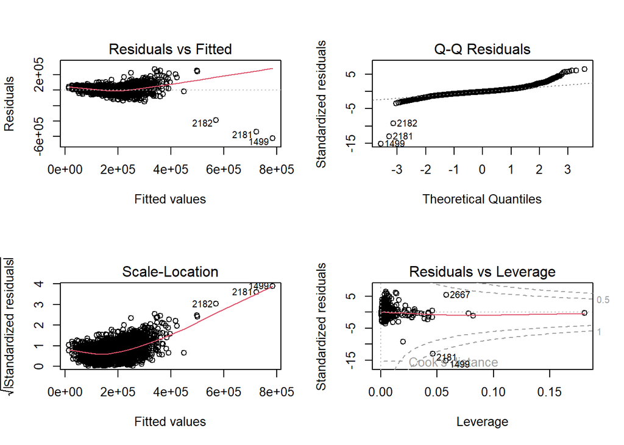

```r
par(mfrow=c(2,2))
plot(model_ames)
```

```r
vif(model_ames)
```

```
## `Total Bsmt SF`   `Gr Liv Area`    Property_age    `1st Flr SF`    `2nd Flr SF`
##        3.047621      122.033664        1.280422       76.477880       89.346416
## `Open Porch SF`  `Wood Deck SF`
##        1.165174        1.117406
```

```r
model_ames_1<-lm(SalePrice~`Total Bsmt SF`+`Property_age`+`1st Flr SF`+`2nd Flr SF`+`Open Porch SF`+`Wood Deck SF`,data = AmesHousing)
summary(model_ames_1)
```

```
##
## Call:
## lm(formula = SalePrice ~ `Total Bsmt SF` + Property_age + `1st Flr SF` +
##     `2nd Flr SF` + `Open Porch SF` + `Wood Deck SF`, data = AmesHousing)
##
## Residuals:
##     Min      1Q  Median      3Q     Max
## -624822  -20548   -2828   16723  272105
##
## Coefficients:
##                  Estimate Std. Error t value Pr(>|t|)
## (Intercept)     47721.903   3654.920  13.057  < 2e-16 ***
## `Total Bsmt SF`    42.159      3.101  13.597  < 2e-16 ***
## Property_age     -808.510     28.975 -27.904  < 2e-16 ***
## `1st Flr SF`       86.135      3.414  25.233  < 2e-16 ***
## `2nd Flr SF`       76.116      1.988  38.284  < 2e-16 ***
## `Open Porch SF`    19.323     12.529   1.542    0.123
## `Wood Deck SF`     44.560      6.553   6.800 1.26e-11 ***
## ---
## Signif. codes:  0 '***' 0.001 '**' 0.01 '*' 0.05 '.' 0.1 ' ' 1
##
## Residual standard error: 42400 on 2923 degrees of freedom
## Multiple R-squared:  0.7189, Adjusted R-squared:  0.7184
## F-statistic:  1246 on 6 and 2923 DF,  p-value: < 2.2e-16
```

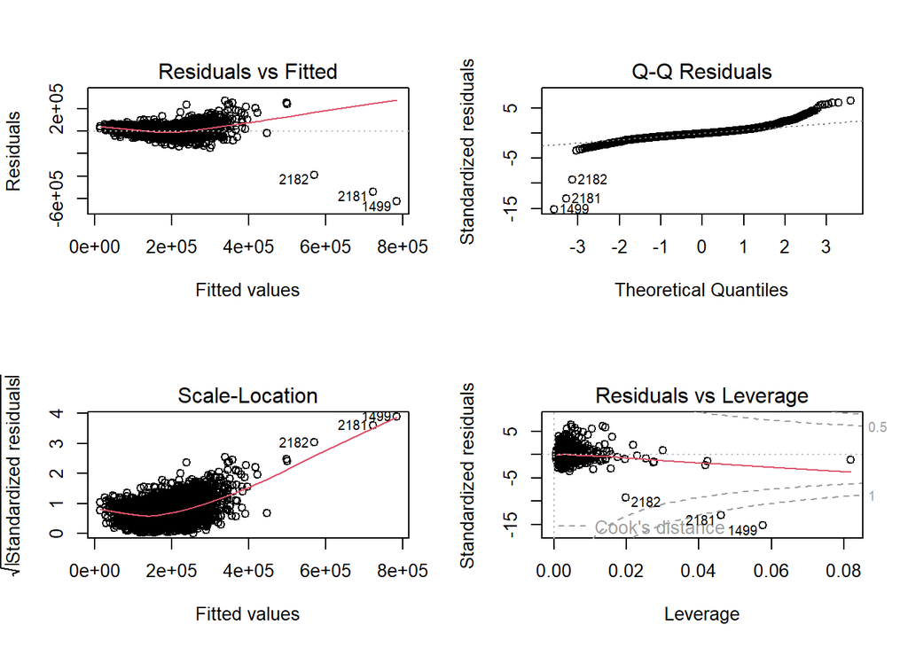

```r
par(mfrow=c(2,2))
plot(model_ames_1)
```

```r
vif(model_ames_1)
```

```
## `Total Bsmt SF`    Property_age    `1st Flr SF`    `2nd Flr SF` `Open Porch SF`
##        3.046368        1.251500        2.916340        1.182219        1.164927
##  `Wood Deck SF`
##        1.117326
```

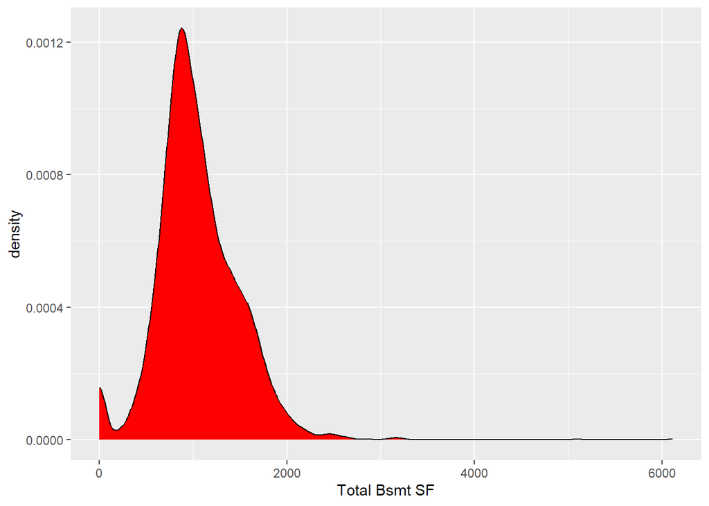

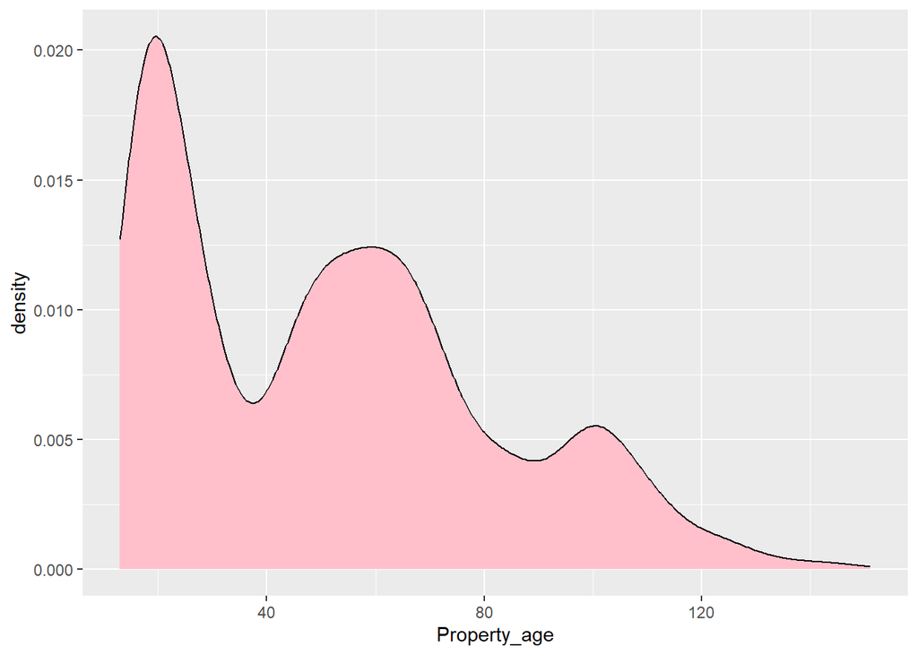

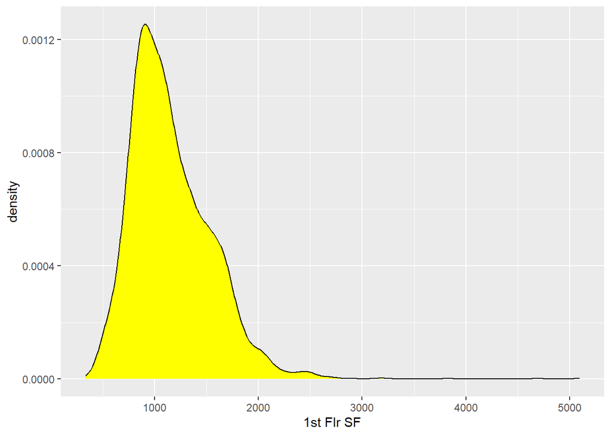

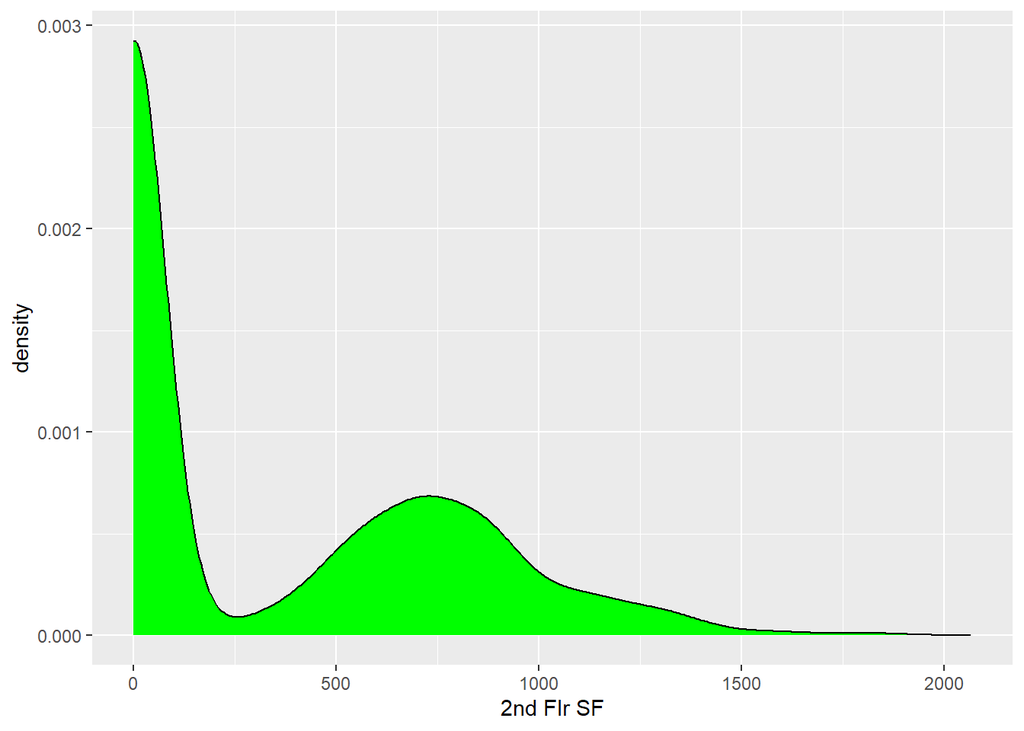

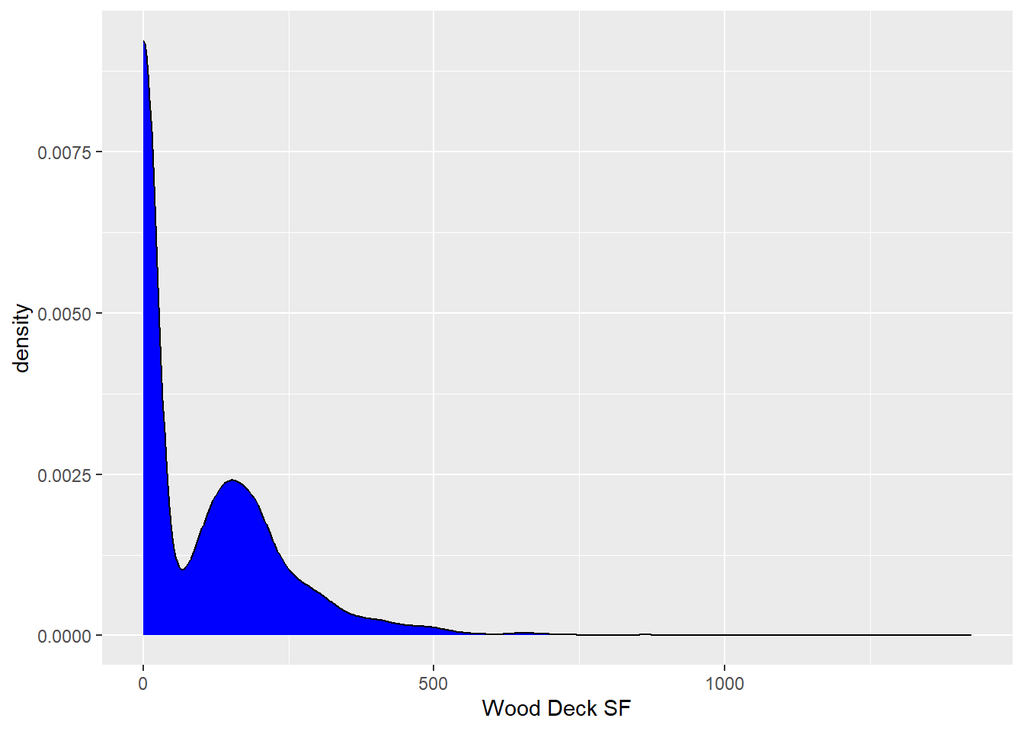

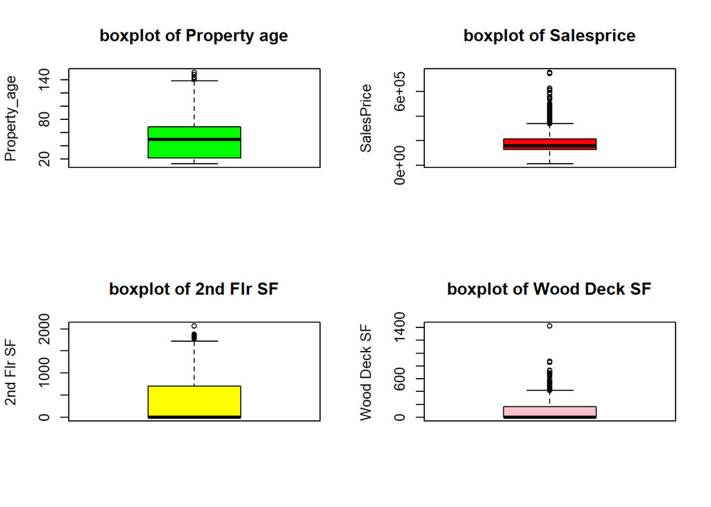

```r
par(mfrow=c(2,2))
boxplot(AmesHousing$`Property_age`,col="green",main="boxplot of Property age",ylab="Property_age")
boxplot(AmesHousing$`SalePrice`,col="red",main="boxplot of Salesprice",ylab="SalesPrice")
boxplot(AmesHousing$`2nd Flr SF`,col="yellow",main="boxplot of 2nd Flr SF",ylab="2nd Flr SF")
boxplot(AmesHousing$`Wood Deck SF`,col="pink",main="boxplot of Wood Deck SF",ylab="Wood Deck SF")
```

```r
AmesHousing$`SalePrice`%>%boxplot.stats()
```

```
## $stats
## [1]  12789 129500 160000 213500 338931
##
## $n
## [1] 2930
##
## $conf
## [1] 157548.1 162451.9
##
## $out
##   [1] 538000 394432 376162 395192 611657 500000 355000 410000 362500 378500
##  [11] 345000 377500 375000 501837 372500 462000 485000 555000 398800 404000
##  [21] 402861 451950 610000 582933 360000 409900 350000 386250 445000 552000
##  [31] 382500 403000 340000 402000 468000 370878 375000 410000 425000 355000
##  [41] 387000 394617 426000 385000 446261 372402 417500 383000 390000 460000
##  [51] 379000 615000 412500 421250 370000 367294 370967 350000 350000 341000
##  [61] 339750 372500 345000 475000 395039 381000 392500 370000 377426 349265
##  [71] 591587 392000 441929 455000 356000 345474 415298 492000 450000 479069
##  [81] 395000 380000 440000 418000 500067 372000 342000 354000 350000 745000
##  [91] 384500 466500 410000 755000 430000 419005 340000 373000 383970 424870
## [101] 360000 359100 375000 392000 457347 545224 356383 556581 361919 535000
## [111] 401179 438780 470000 412083 342643 465000 415000 345000 344133 360000
## [121] 372397 378000 374000 437154 348000 625000 405000 350000 584500 423000
## [131] 405749 385000 475000 415000 375000 369900 359900
```

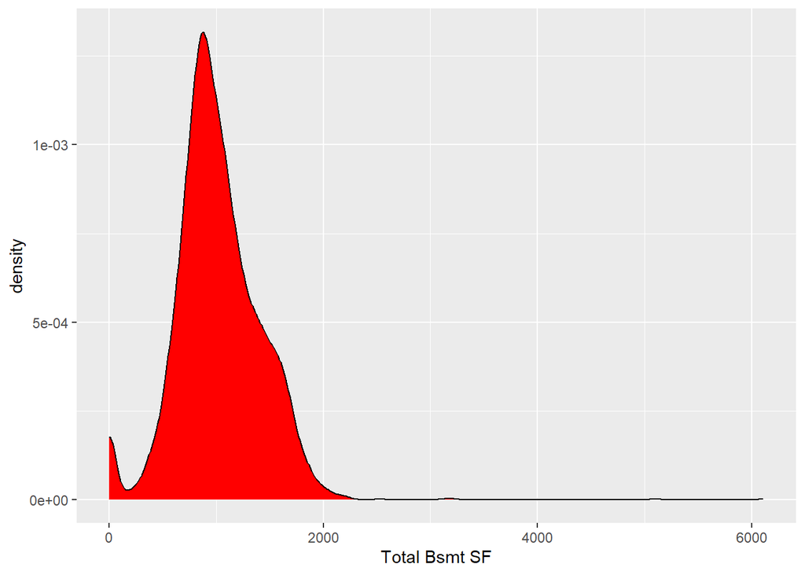

```r
AmesHousing_new<-AmesHousing%>%filter(`SalePrice`<=338931)
AmesHousing_new%>%ggplot(aes(`Total Bsmt SF`))+geom_density(fill="red")
```

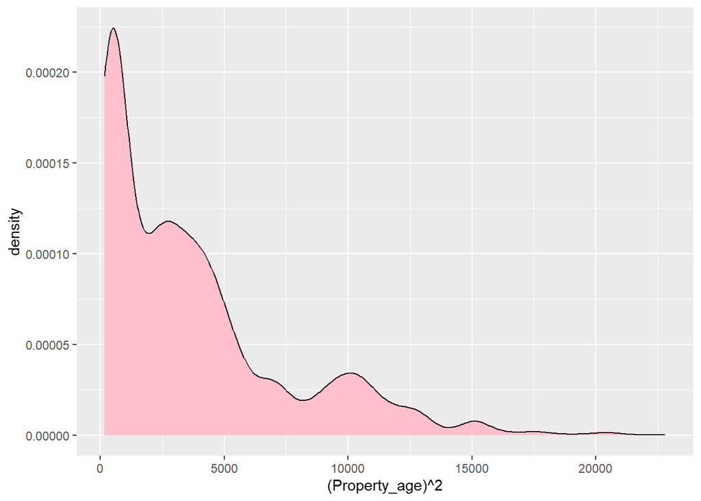

```r
AmesHousing_new%>%ggplot(aes((`Property_age`)^2))+geom_density(fill="pink")
```

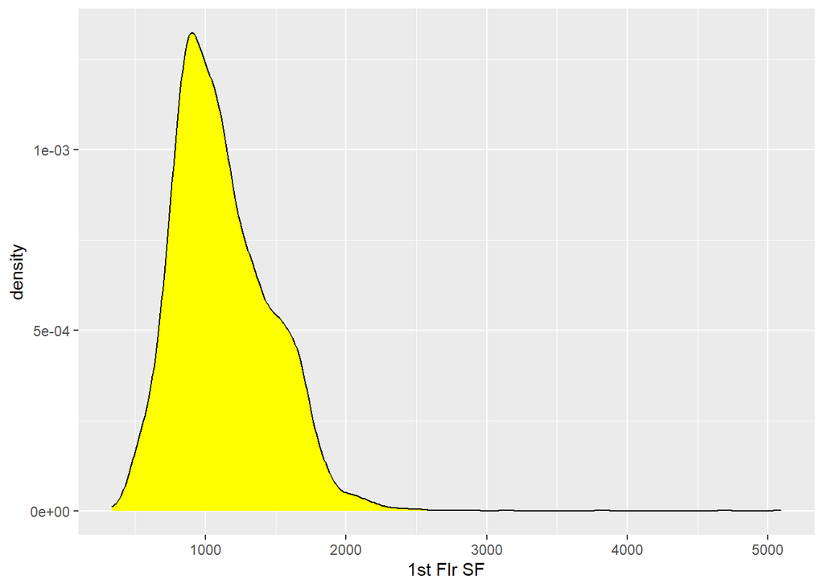

```r
AmesHousing_new%>%ggplot(aes(`1st Flr SF`))+geom_density(fill="yellow")
```

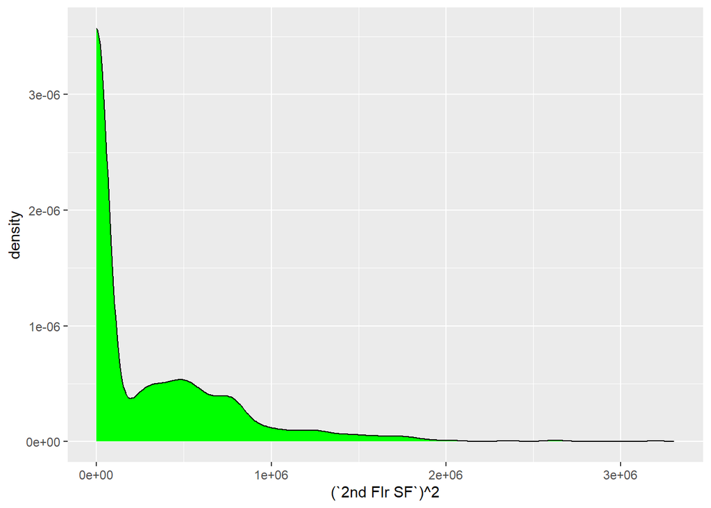

```r
AmesHousing_new%>%ggplot(aes((`2nd Flr SF`)^2))+geom_density(fill="green")
```

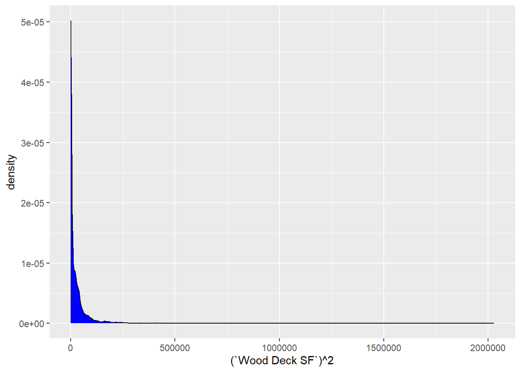

```r
AmesHousing_new%>%ggplot(aes((`Wood Deck SF`)^2))+geom_density(fill="blue")
```

```r
vif(model_ames)
```

```
## `Total Bsmt SF`   `Gr Liv Area`    Property_age    `1st Flr SF`    `2nd Flr SF`
##        3.047621      122.033664        1.280422       76.477880       89.346416
## `Open Porch SF`  `Wood Deck SF`
##        1.165174        1.117406
```

```r
model_ames_2<-lm(log(SalePrice)~`Total Bsmt SF`+(`Property_age`)+`1st Flr SF`+(`2nd Flr SF`)+(`Wood Deck SF`),data = AmesHousing)
summary(model_ames_2)
```

```
##
## Call:
## lm(formula = log(SalePrice) ~ `Total Bsmt SF` + (Property_age) +
##     `1st Flr SF` + (`2nd Flr SF`) + (`Wood Deck SF`), data = AmesHousing)
##
## Residuals:
##      Min       1Q   Median       3Q      Max
## -2.97727 -0.08320  0.01149  0.10422  0.86386
##
## Coefficients:
##                   Estimate Std. Error t value Pr(>|t|)
## (Intercept)      1.145e+01  1.777e-02 644.041  < 2e-16 ***
## `Total Bsmt SF`  2.088e-04  1.504e-05  13.885  < 2e-16 ***
## Property_age    -5.116e-03  1.402e-04 -36.477  < 2e-16 ***
## `1st Flr SF`     4.051e-04  1.648e-05  24.580  < 2e-16 ***
## `2nd Flr SF`     3.860e-04  9.336e-06  41.344  < 2e-16 ***
## `Wood Deck SF`   2.250e-04  3.177e-05   7.081 1.78e-12 ***
## ---
## Signif. codes:  0 '***' 0.001 '**' 0.01 '*' 0.05 '.' 0.1 ' ' 1
##
## Residual standard error: 0.2062 on 2924 degrees of freedom
## Multiple R-squared:  0.7444, Adjusted R-squared:  0.744
## F-statistic:  1703 on 5 and 2924 DF,  p-value: < 2.2e-16
```

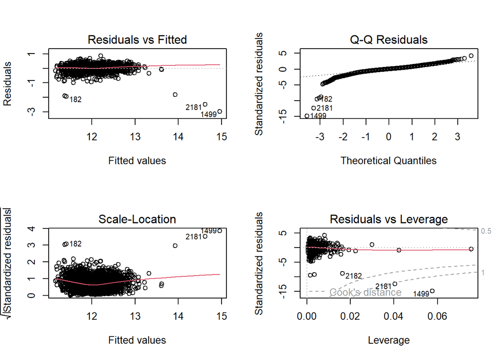

```r
par(mfrow=c(2,2))
plot(model_ames_2)
```

```r
vif(model_ames_2)
```

```
## `Total Bsmt SF`    Property_age    `1st Flr SF`    `2nd Flr SF`  `Wood Deck SF`
##        3.028849        1.239243        2.873467        1.101678        1.109966
```

```r
AIC(model_ames_2)
```

```
## [1] -928.6907
```

```r
BIC(model_ames_2)
```

```
## [1] -886.8114
```

```
## Start:  AIC=62444.49
## SalePrice ~ `Total Bsmt SF` + Property_age + `1st Flr SF` + `2nd Flr SF` +
##     `Wood Deck SF`
##
##                   Df  Sum of Sq        RSS   AIC
## <none>                          5.2580e+12 62444
## - `Wood Deck SF`   1 8.0611e+10 5.3386e+12 62487
## - `Total Bsmt SF`  1 3.4000e+11 5.5980e+12 62626
## - `1st Flr SF`     1 1.1787e+12 6.4367e+12 63035
## - Property_age     1 1.4289e+12 6.6869e+12 63147
## - `2nd Flr SF`     1 2.8867e+12 8.1447e+12 63725
```

```
##
## Call:
## lm(formula = SalePrice ~ `Total Bsmt SF` + Property_age + `1st Flr SF` +
##     `2nd Flr SF` + `Wood Deck SF`, data = AmesHousing)
##
## Coefficients:
##     (Intercept)  `Total Bsmt SF`     Property_age     `1st Flr SF`
##        47555.78            42.52          -812.93            86.77
##    `2nd Flr SF`   `Wood Deck SF`
##           76.92            43.74
```